# Codebook draft for DBS and BIO vars

Shaina Trevino

2023-12-15

# Allostatic Load Assessment

## Dried Blood Spot Data Collection

These data are in the `dbs_archive.xlsx` file where each construct domain is a separate tab.

The seven biological constructs assessed were cholesterol, high-density lipoprotein cholesterol, Triglycerides, c-reactive protein, Epstein-Barr virus, hemoglobin A1C, and Interleukin-6..

### Cholesterol (CHO) Description

These data include variables related to the cholesterol assessment, including direct and plasma equivalent (PE) cholesterol values for participants. Higher values indicate higher cholesterol. The PE cholesterol value was used to calculate allostatic load indicators.

The missing data rule was not applied since composite variables were based on a single item. Missing data for each variable is presented in the descriptive statistics table below.

#### Value Labels

The value labels for all `_note` variables (`cho_punch_note`, `cho_assay_note`, and `cho_result_note`) are below:

| 1 | 4 | 5 | 37 | 42 |
| --- | --- | --- | --- | --- |
| Blank punch | Small spot, <80% | Non-circular dried blood spot | Punch did not elute | Blood from filter paper touched inside back cover |

Allostatic load indicators, `cho_cal` and `cho_pal` are dichotomous:

| 0 | 1 |
| --- | --- |
| No | Yes |

#### Variables

All CHO variables are presented in the following table.

| Variable | Description | Notes |
| --- | --- | --- |
| dbs_id | Unique ID for each assay |  |
| family | Participant ID |  |
| cho_direct | Direct cholesterol analyte concentrate obtained from dried blood spot |  |
| cho_pe | Plasma-equivalent cholesterol analyte concentration |  |
| cho_punch_note | Note made by technician during sample preparation (punching) | When multiple notes were provided, they are separated by a semi-colon |
| cho_assay_note | Note made by technician during assay | When multiple notes were provided, they are separated by a semi-colon |
| cho_result_note | Note indicating reportability of values | When multiple notes were provided, they are separated by a semi-colon |
| cho_plate | ID for the plate used during assay |  |
| cho_date | Date of assay |  |
| cho_cal | Clinical allostatic load indicator for out-of-range cholesterol |  |
| cho_pal | Percentile-based allostatic load indicator for out-of-range cholesterol |  |

#### Composite Variables

Using the plasma-equivalent cholesterol value, two allostatic load indicators were calculated. One based on the clinical cut-off for high cholesterol (`cho_cal`) and the other is a percentile-based cut-off for high cholesterol (`cho_pal`) defined as the top 25% of cholesterol values.

| Variable Name | Description (# of items) | Composite Construction | Range* |
| --- | --- | --- | --- |
| cho_cal | Allostatic load indicator based on clinical cut-off for high cholesterol (1) | `cho_pe` > 199 | 0-1 |
| cho_pal | Allostatic load indicator based on top 25% of cholesterol values (1) | Top 25% of observed `cho_pe` values | 0-1 |

*Range of possible values

#### Descriptive Statistics

Descriptive statistics are presented below for key CHO variables.

**Raw cholesterol values:**

| Variable | Mean | SD | Range* | % Missing |
| --- | --- | --- | --- | --- |
| cho_direct | 334.49 | 36.70 | 247-441 | 12.71% |
| cho_pe | 148.72 | 27.88 | 82-230 | 12.71% |

*Range of data values

**Allostatic load indicators:**

| Variable | No N | No % | Yes N | Yes % | % Missing |  |
| --- | --- | --- | --- | --- | --- | --- |
| cho_cal | 98 | 83.1% | 5 | 4.2% |  | 12.71% |
| cho_pal | 77 | 65.3% | 26 | 22% | 12.71% |  |

**Data collection notes:**

| Variable | Blank punch N | Blank punch % | Small spot, N | Small spot, % | Non-circular N | Non-circular % | Did not elute N | Did not elute % | Touched cover N | Touched cover % | % NA* |  |
| --- | --- | --- | --- | --- | --- | --- | --- | --- | --- | --- | --- | --- |
| cho_punch_note | 7 | 5.4% | 74 | 57.4% | 6 | 4.7% | 0 | 0% | 11 | 8.5% |  | 24% |
| cho_assay_note | 7 | 5.9% | 0 | 0% | 0 | 0% | 8 | 6.8% | 0 | 0% | 87.3% |  |
| cho_result_note | 7 | 5.9% | 0 | 0% | 0 | 0% | 8 | 6.8% | 0 | 0% | 87.3% |  |

*NA = Not Applicable

#### Distributions

Distributions are presented below for the allostatic load indicators.

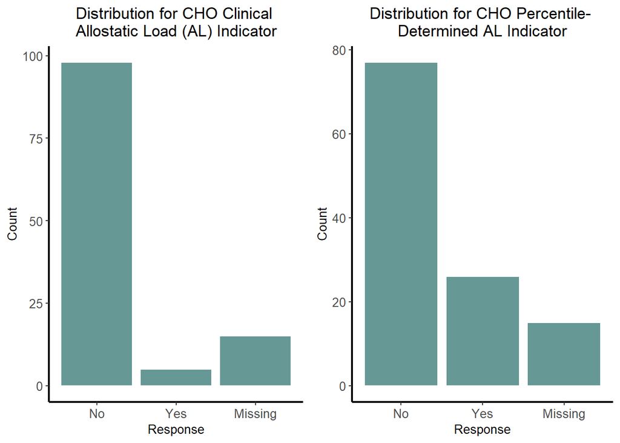

#### Clinical Categories

The distribution for plasma-equivalent cholesterol values (`cho_pe`) alongside the clinical and percentile-determined allostatic load cutoffs are presented below.

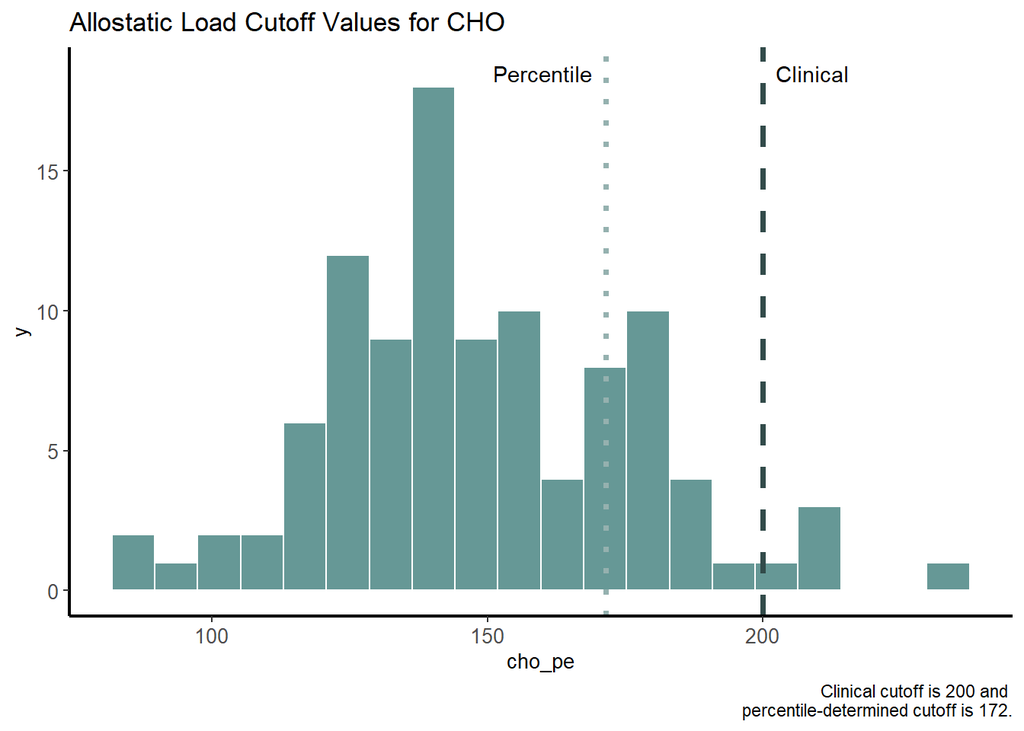

### High-Density Lipoprotein Cholesterol (HDL) Description

These data include variables related to the HDL cholesterol assessment, including direct and plasma equivalent (PE) HDL cholesterol values for participants. Higher values indicate higher HDL cholesterol. The PE value was used to calculate allostatic load indicators.

The missing data rule was not applied since composite variables were based on a single item. Missing data for each variable is presented in the descriptive statistics table below.

#### Value Labels

The value labels for all `_note` variables (`hdl_punch_note`, `hdl_assay_note`, and `hdl_result_note`) are below:

| 1 | 4 | 5 | 37 | 42 |
| --- | --- | --- | --- | --- |
| Blank punch | Small spot, <80% | Non-circular dried blood spot | Punch did not elute | Blood from filter paper touched inside back cover |

Allostatic load indicators, `hdl_cal` and `hdl_pal` are dichotomous:

| 0 | 1 |
| --- | --- |
| No | Yes |

#### Variables

All HDL variables are presented in the following table.

| Variable | Description | Notes |
| --- | --- | --- |
| dbs_id | Unique ID for each assay |  |
| family | Participant ID |  |
| hdl_direct | Direct HDL cholesterol analyte concentrate obtained from dried blood spot |  |
| hdl_pe | Plasma-equivalent HDL cholesterol analyte concentration |  |
| hdl_punch_note | Note made by technician during sample preparation (punching) | When multiple notes were provided, they are separated by a semi-colon |
| hdl_assay_note | Note made by technician during assay | When multiple notes were provided, they are separated by a semi-colon |
| hdl_result_note | Note indicating reportability of values | When multiple notes were provided, they are separated by a semi-colon |
| hdl_plate | ID for the plate used during assay |  |
| hdl_date | Date of assay |  |
| hdl_cal | Clinical allostatic load indicator for out-of-range HDL cholesterol |  |
| hdl_pal | Percentile-based allostatic load indicator for out-of-range HDL cholesterol |  |

#### Composite Variables

[output not shown]

*Range of possible values

#### Descriptive Statistics

Descriptive statistics are presented below for key HDL variables.

**Raw HDL cholesterol values:**

| Variable | Mean | SD | Range* | % Missing |
| --- | --- | --- | --- | --- |
| hdl_direct | 63.97 | 9.82 | 40-97 | 12.71% |
| hdl_pe | 45.55 | 11.41 | 18-84 | 12.71% |

*Range of data values

**Allostatic load indicators:**

| Variable | No N | No % | Yes N | Yes % | % Missing |  |
| --- | --- | --- | --- | --- | --- | --- |
| hdl_cal | 72 | 61% | 31 | 26.3% |  | 12.71% |
| hdl_pal | 77 | 65.3% | 26 | 22% | 12.71% |  |

**Data collection notes:**

| Variable | Blank punch N | Blank punch % | Small spot, N | Small spot, % | Non-circular N | Non-circular % | Did not elute N | Did not elute % | Touched cover N | Touched cover % | % NA* |  |
| --- | --- | --- | --- | --- | --- | --- | --- | --- | --- | --- | --- | --- |
| hdl_punch_note | 7 | 5.4% | 74 | 57.4% | 6 | 4.7% | 0 | 0% | 11 | 8.5% |  | 24% |
| hdl_assay_note | 7 | 5.9% | 0 | 0% | 0 | 0% | 8 | 6.8% | 0 | 0% | 87.3% |  |
| hdl_result_note | 7 | 5.9% | 0 | 0% | 0 | 0% | 8 | 6.8% | 0 | 0% | 87.3% |  |

*NA = Not Applicable

#### Distributions

Distributions are presented below for the allostatic load indicators.

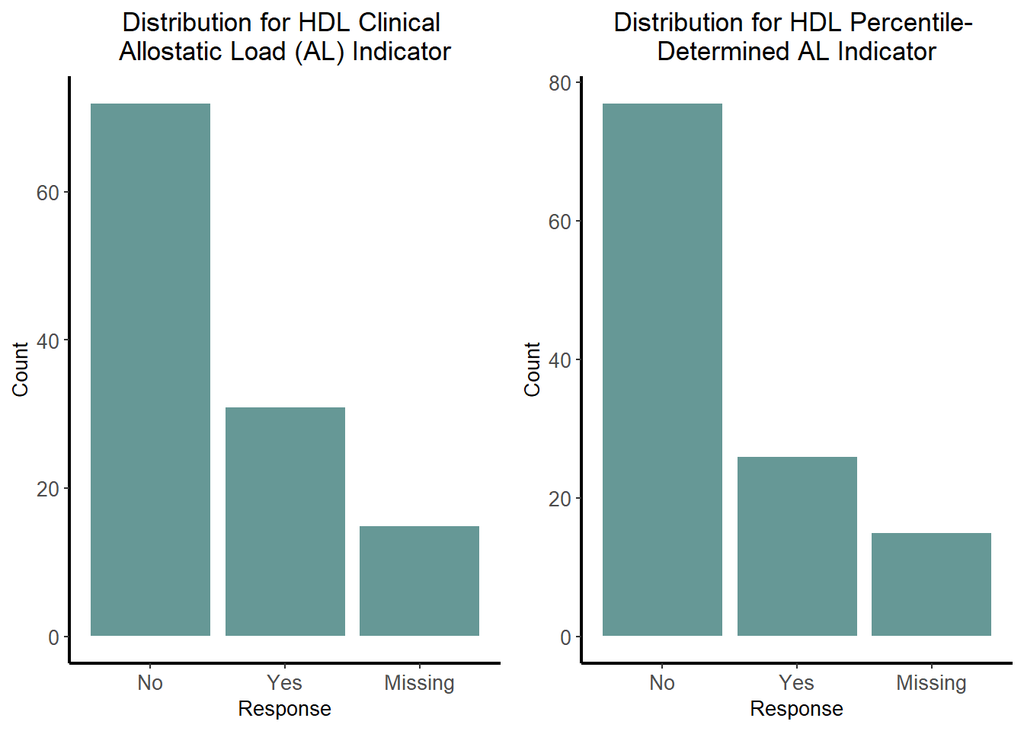

#### Clinical Categories

The distribution for plasma-equivalent HDL cholesterol values (`hdl_pe`) alongside the clinical and percentile-determined allostatic load cutoffs are presented below.

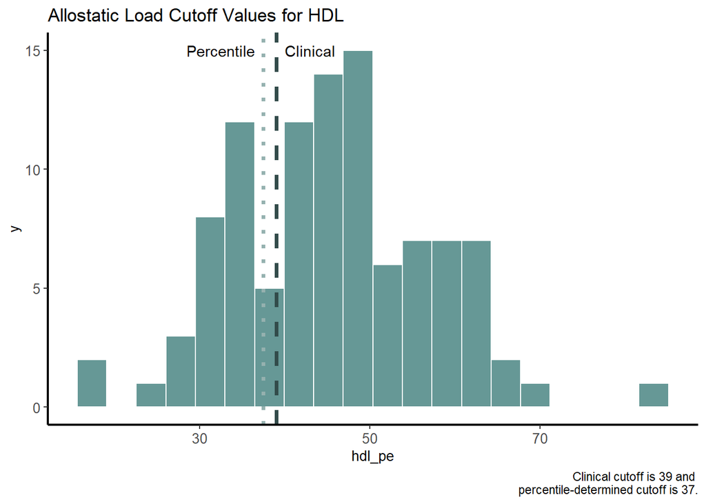

### Triglycerides (TRG) Description

These data include variables related to the triglycerides assessment, including direct and plasma equivalent (PE) triglyceride values for participants. Higher values indicate higher triglycerides. The PE triglyceride value was used to calculate allostatic load indicators.

The missing data rule was not applied since composite variables were based on a single item. Missing data for each variable is presented in the descriptive statistics table below.

#### Value Labels

The value labels for all `_note` variables (`trg_punch_note`, `trg_assay_note`, and `trg_result_note`) are below:

| 1 | 4 | 5 | 37 | 42 |
| --- | --- | --- | --- | --- |
| Blank punch | Small spot, <80% | Non-circular dried blood spot | Punch did not elute | Blood from filter paper touched inside back cover |

Allostatic load indicators, `trg_cal` and `trg_pal` are dichotomous:

| 0 | 1 |
| --- | --- |
| No | Yes |

#### Variables

All TRG variables are presented in the following table.

| Variable | Description | Notes |
| --- | --- | --- |
| dbs_id | Unique ID for each assay |  |
| family | Participant ID |  |
| trg_direct | Direct triglycerides analyte concentrate obtained from dried blood spot |  |
| trg_pe | Plasma-equivalent triglycerides analyte concentration |  |
| trg_punch_note | Note made by technician during sample preparation (punching) | When multiple notes were provided, they are separated by a semi-colon |
| trg_assay_note | Note made by technician during assay | When multiple notes were provided, they are separated by a semi-colon |
| trg_result_note | Note indicating reportability of values | When multiple notes were provided, they are separated by a semi-colon |
| trg_plate | ID for the plate used during assay |  |
| trg_date | Date of assay |  |
| trg_cal | Clinical allostatic load indicator for out-of-range triglycerides |  |
| trg_pal | Percentile-based allostatic load indicator for out-of-range triglycerides |  |

#### Composite Variables

Using the plasma-equivalent triglyceride value, two allostatic load indicators were calculated. One based on the clinical cut-off for high triglycerides (`trg_cal`) and the other is a percentile-based cut-off for high triglycerides (`trg_pal`) defined as the top 25% of triglyceride values.

| Variable Name | Description (# of items) | Composite Construction | Range* |
| --- | --- | --- | --- |
| trg_cal | Allostatic load indicator based on clinical cut-off for high triglycerides (1) | `trg_pe` > 149 | 0-1 |
| trg_pal | Allostatic load indicator based on top 25% of triglyceride values (1) | Top 25% of observed `trg_pe` values | 0-1 |

*Range of possible values

#### Descriptive Statistics

Descriptive statistics are presented below for key TRG variables.

**Raw triglyceride values:**

| Variable | Mean | SD | Range* | % Missing |
| --- | --- | --- | --- | --- |
| trg_direct | 145.46 | 65.20 | 56-368 | 12.71% |
| trg_pe | 86.07 | 25.44 | 51-173 | 12.71% |

*Range of data values

**Allostatic load indicators:**

| Variable | No N | No % | Yes N | Yes % | % Missing |  |
| --- | --- | --- | --- | --- | --- | --- |
| trg_cal | 100 | 84.7% | 3 | 2.5% |  | 12.71% |
| trg_pal | 75 | 63.6% | 28 | 23.7% | 12.71% |  |

**Data collection notes:**

| Variable | Blank punch N | Blank punch % | Small spot, N | Small spot, % | Non-circular N | Non-circular % | Did not elute N | Did not elute % | Touched cover N | Touched cover % | % NA* |  |
| --- | --- | --- | --- | --- | --- | --- | --- | --- | --- | --- | --- | --- |
| trg_punch_note | 7 | 5.4% | 74 | 57.4% | 6 | 4.7% | 0 | 0% | 11 | 8.5% |  | 24% |
| trg_assay_note | 7 | 5.9% | 0 | 0% | 0 | 0% | 8 | 6.8% | 0 | 0% | 87.3% |  |
| trg_result_note | 7 | 5.9% | 0 | 0% | 0 | 0% | 8 | 6.8% | 0 | 0% | 87.3% |  |

*NA = Not Applicable

#### Distributions

Distributions are presented below for the allostatic load indicators.

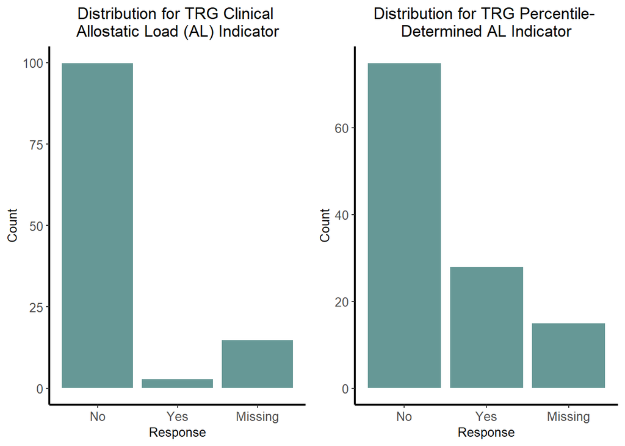

#### Clinical Categories

The distribution for plasma-equivalent triglyceride values (`trg_pe`) alongside the clinical and percentile-determined allostatic load cutoffs are presented below.

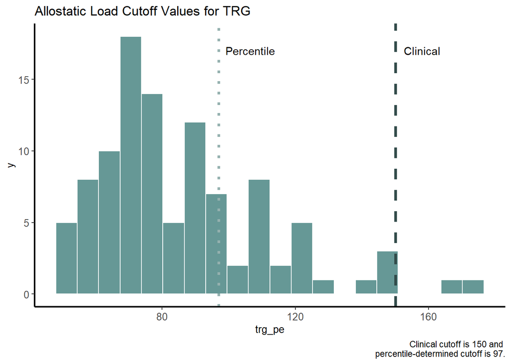

### C-Reactive Protein (CRP) Description

These data include variables related to the c-reactive protein assessment, including direct and plasma equivalent (PE) c-reactive protein values for participants. Higher values indicate higher c-reactive protein. The PE value was used to calculate allostatic load indicators.

The missing data rule was not applied since composite variables were based on a single item. Missing data for each variable is presented in the descriptive statistics table below.

#### Value Labels

The value labels for all `_note` variables (`crp_punch_note`, `crp_assay_note`, and `crp_result_note`) are below:

| 1 | 3 | 4 | 5 | 29 | 42 |
| --- | --- | --- | --- | --- | --- |
| Blank punch | Smeared Drops/ Inconsistent Absorption | Small spot, <80% | Non-circular dried blood spot | Below lower limit of detection (LLoD) | Blood from filter paper touched inside back cover |

Allostatic load indicators, `crp_cal` and `crp_pal` are dichotomous:

| 0 | 1 |
| --- | --- |
| No | Yes |

#### Variables

All CRP variables are presented in the following table.

| Variable | Description | Notes |
| --- | --- | --- |
| dbs_id | Unique ID for each assay |  |
| family | Participant ID |  |
| crp_direct | Direct c-reactive protein analyte concentrate obtained from dried blood spot |  |
| crp_pe | Plasma-equivalent c-reactive protein analyte concentration |  |
| crp_punch_note | Note made by technician during sample preparation (punching) | When multiple notes were provided, they are separated by a semi-colon |
| crp_assay_note | Note made by technician during assay | When multiple notes were provided, they are separated by a semi-colon |
| crp_result_note | Note indicating reportability of values | When multiple notes were provided, they are separated by a semi-colon |
| crp_plate | ID for the plate used during assay |  |
| crp_date | Date of assay |  |
| crp_cal | Clinical allostatic load indicator for out-of-range c-reactive protein |  |
| crp_pal | Percentile-based allostatic load indicator for out-of-range c-reactive protein |  |

#### Composite Variables

Using the plasma-equivalent c-reactive protein value, two allostatic load indicators were calculated. One based on the clinical cut-off for high c-reactive protein (`crp_cal`) and the other is a percentile-based cut-off for high c-reactive protein (`crp_pal`) defined as the top 25% of c-reactive protein values.

| Variable Name | Description (# of items) | Composite Construction | Range* |
| --- | --- | --- | --- |
| crp_cal | Allostatic load indicator based on clinical cut-off for high c-reactive protein (1) | `crp_pe` > 0.2 | 0-1 |
| crp_pal | Allostatic load indicator based on top 25% of c-reactive protein values (1) | Top 25% of observed `crp_pe` values | 0-1 |

*Range of possible values

#### Descriptive Statistics

Descriptive statistics are presented below for key CRP variables.

**Raw c-reactive protein values:**

| Variable | Mean | SD | Range* | % Missing |
| --- | --- | --- | --- | --- |
| crp_direct | 2.24 | 2.73 | 0.17-19.3 | 6.78% |
| crp_pe | 4.07 | 5.73 | 0.21-42.39 | 6.78% |

*Range of data values

**Allostatic load indicators:**

| Variable | No N | No % | Yes N | Yes % | % Missing |  |
| --- | --- | --- | --- | --- | --- | --- |
| crp_cal | 4 | 3.4% | 107 | 90.7% |  | 5.93% |
| crp_pal | 83 | 70.3% | 28 | 23.7% | 5.93% |  |

**Data collection notes:**

| Variable | Blank punch N | Blank punch % | Smeared drops N | Smeared drops % | Small spot, N | Small spot, % | Non-circular N | Non-circular % | Below limit N | Below limit % | Touched cover N | Touched cover % | % NA* |  |
| --- | --- | --- | --- | --- | --- | --- | --- | --- | --- | --- | --- | --- | --- | --- |
| crp_punch_note | 7 | 5.1% | 3 | 2.2% | 75 | 54.3% | 9 | 6.5% | 0 | 0% | 15 | 10.9% |  | 21% |
| crp_assay_note | 7 | 5.9% | 0 | 0% | 0 | 0% | 0 | 0% | 1 | 0.8% | 0 | 0% | 93.2% |  |
| crp_result_note | 7 | 5.9% | 0 | 0% | 0 | 0% | 0 | 0% | 1 | 0.8% | 0 | 0% | 93.2% |  |

*NA = Not Applicable

#### Distributions

Distributions are presented below for the allostatic load indicators.

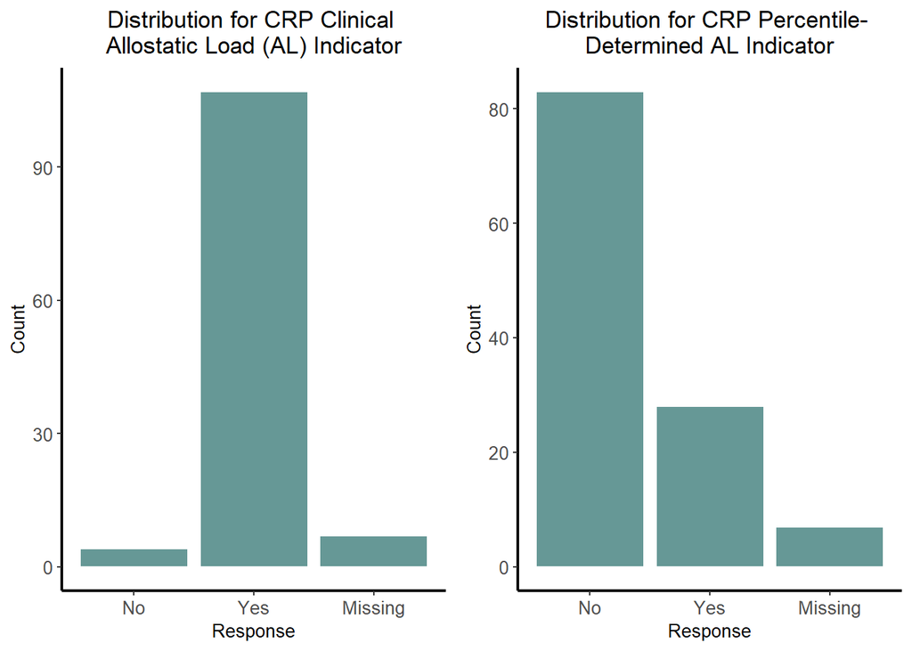

#### Clinical Categories

The distribution for plasma-equivalent c-reactive protein values (`crp_pe`) alongside the clinical and percentile-determined allostatic load cutoffs are presented below.

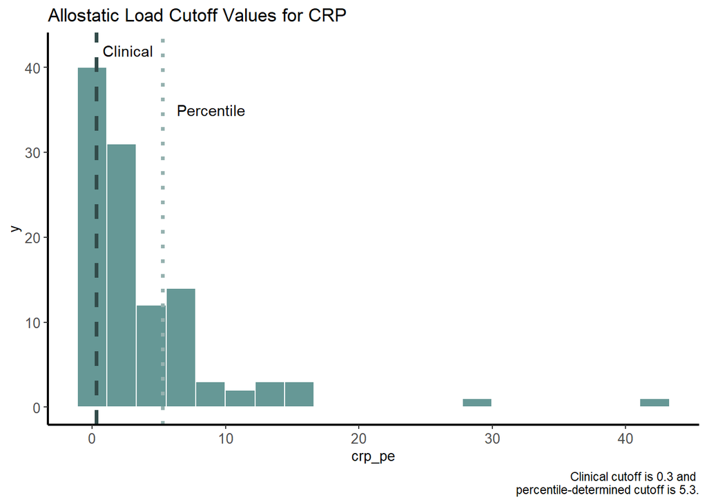

### Epstein-Barr virus (EBV) Description

The missing data rule was not applied since composite variables were based on a single item. Missing data for each variable is presented in the descriptive statistics table below.

#### Value Labels

The value labels for all `_note` variables (`ebv_punch_note`, `ebv_assay_note`, and `ebv_result_note`) are below:

| 1 | 3 | 4 | 5 | 12 | 13 | 42 |
| --- | --- | --- | --- | --- | --- | --- |
| Blank punch | Smeared Drops/ Inconsistent Absorption | Small spot, <80% | Non-circular dried blood spot | Drop outside printed circle | No DBS remains | Blood from filter paper touched inside back cover |

The allostatic load indicator, `ebv_pal`, is dichotomous:

| 0 | 1 |
| --- | --- |
| No | Yes |

#### Variables

All EBV variables are presented in the following table.

| Variable | Description | Notes |
| --- | --- | --- |
| dbs_id | Unique ID for each assay |  |
| family | Participant ID |  |
| ebv_direct | Direct Epstein-Barr virus analyte concentrate obtained from dried blood spot |  |
| ebv_pe | Plasma-equivalent Epstein-Barr virus analyte concentration |  |
| ebv_punch_note | Note made by technician during sample preparation (punching) | When multiple notes were provided, they are separated by a semi-colon |
| ebv_assay_note | Note made by technician during assay | When multiple notes were provided, they are separated by a semi-colon |
| ebv_result_note | Note indicating reportability of values | When multiple notes were provided, they are separated by a semi-colon |
| ebv_plate | ID for the plate used during assay |  |
| ebv_date | Date of assay |  |
| ebv_pal | Percentile-based allostatic load indicator for out-of-range Epstein-Barr virus |  |

#### Composite Variables

| Variable Name | Description (# of items) | Composite Construction | Range* |
| --- | --- | --- | --- |
| ebv_pal | Allostatic load indicator based on top 25% of Epstein-Barr virus values (1) | Top 25% of observed `ebv_pe` values | 0-1 |

*Range of possible values

#### Descriptive Statistics

Descriptive statistics are presented below for key EBV variables.

**Raw Epstein-Barr virus values:**

| Variable | Mean | SD | Range* | % Missing |
| --- | --- | --- | --- | --- |
| ebv_direct | 176.36 | 141.38 | 22-630 | 10.17% |
| ebv_pe | 269.93 | 220.05 | 29-976 | 10.17% |

*Range of data values

**Allostatic load indicators:**

| Variable | No N | No % | Yes N | Yes % | % Missing |  |
| --- | --- | --- | --- | --- | --- | --- |
| ebv_pal | 79 | 66.9% | 27 | 22.9% |  | 10.17% |

**Data collection notes:**

| Variable | Blank punch N | Blank punch % | Smeared drop N | Smeared drop % | Small spot, N | Small spot, % | Non-circular N | Non-circular % | Outside circle N | Outside circle % | No DBS remains N | No DBS remains % | Touched cover N | Touched cover % | % NA* |  |
| --- | --- | --- | --- | --- | --- | --- | --- | --- | --- | --- | --- | --- | --- | --- | --- | --- |
| ebv_punch_note | 12 | 8.5% | 4 | 2.8% | 75 | 53.2% | 9 | 6.4% | 1 | 0.7% | 1 | 0.7% | 15 | 10.6% |  | 17% |
| ebv_assay_note | 12 | 10.2% | 0 | 0% | 0 | 0% | 0 | 0% | 0 | 0% | 0 | 0% | 0 | 0% | 89.8% |  |
| ebv_result_note | 12 | 10.2% | 0 | 0% | 0 | 0% | 0 | 0% | 0 | 0% | 0 | 0% | 0 | 0% | 89.8% |  |

*NA = Not Applicable

#### Distributions

Distributions are presented below for the percentile-based allostatic load indicator.

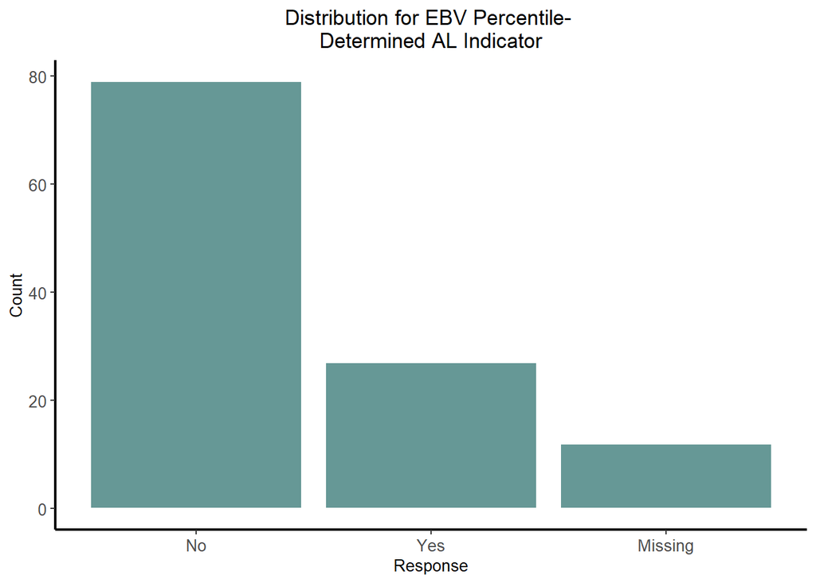

#### Clinical Categories

The distribution for plasma-equivalent Epstein-Barr virus values (`ebv_pe`) alongside the percentile-determined allostatic load cutoff is presented below.

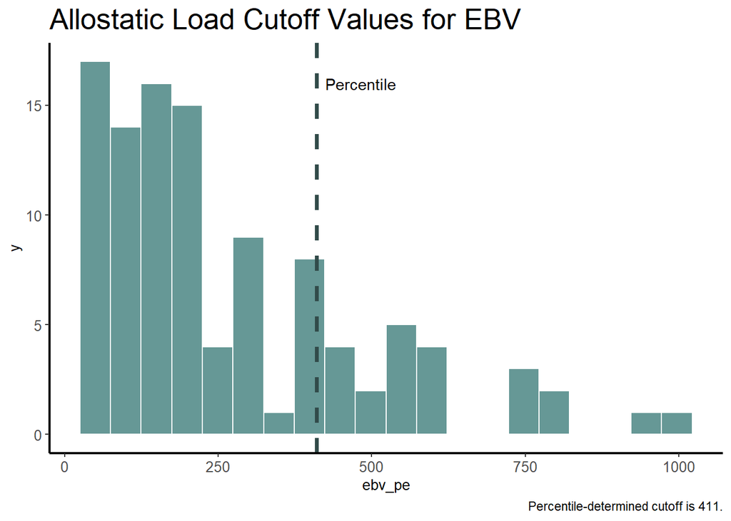

### Hemoglobin A1C (A1C) Description

The missing data rule was not applied since composite variables were based on a single item. Missing data for each variable is presented in the descriptive statistics table below.

#### Value Labels

The value labels for all `_note` variables (`a1c_punch_note`, `a1c_assay_note`, and `a1c_result_note`) are below:

| 1 | 3 | 4 | 5 | 13 | 37 | 42 |
| --- | --- | --- | --- | --- | --- | --- |
| Blank punch | Smeared Drops/ Inconsistent Absorption | Small spot, <80% | Non-circular dried blood spot | No DBS remains | Punch did not elute | Blood from filter paper touched inside back cover |

Allostatic load indicators, `a1c_cal` and `a1c_pal` are dichotomous:

| 0 | 1 |
| --- | --- |
| No | Yes |

#### Variables

All A1C variables are presented in the following table.

| Variable | Description | Notes |
| --- | --- | --- |
| dbs_id | Unique ID for each assay |  |
| family | Participant ID |  |
| a1c_hb | Hemoglobin A1C analyte concentrate obtained from dried blood spot |  |
| a1c_punch_note | Note made by technician during sample preparation (punching) | When multiple notes were provided, they are separated by a semi-colon |
| a1c_assay_note | Note made by technician during assay | When multiple notes were provided, they are separated by a semi-colon |
| a1c_result_note | Note indicating reportability of values | When multiple notes were provided, they are separated by a semi-colon |
| a1c_plate | ID for the plate used during assay |  |
| a1c_date | Date of assay |  |
| a1c_cal | Clinical allostatic load indicator for out-of-range hemoglobin A1C |  |
| a1c_pal | Percentile-based allostatic load indicator for out-of-range hemoglobin A1C |  |

#### Composite Variables

Using the hemoglobin A1C value, two allostatic load indicators were calculated. One based on the clinical cut-off for high hemoglobin A1C (`a1c_cal`) and the other is a percentile-based cut-off for high hemoglobin A1C (`a1c_pal`) defined as the top 25% of hemoglobin A1C values.

| Variable Name | Description (# of items) | Composite Construction | Range* |
| --- | --- | --- | --- |
| a1c_cal | Allostatic load indicator based on clinical cut-off for high hemoglobin A1C (1) | `a1c_hb` > 6.4 | 0-1 |
| a1c_pal | Allostatic load indicator based on top 25% of hemoglobin A1C values (1) | Top 25% of observed `a1c_hb` values | 0-1 |

*Range of possible values

#### Descriptive Statistics

Descriptive statistics are presented below for key A1C variables.

**Raw hemoglobin A1C values:**

| Variable | Mean | SD | Range* | % Missing |
| --- | --- | --- | --- | --- |
| a1c_hb | 5.80 | 0.77 | 4.9-12.1 | 4.24% |

*Range of data values

**Allostatic load indicators:**

| Variable | No N | No % | Yes N | Yes % | % Missing |  |
| --- | --- | --- | --- | --- | --- | --- |
| a1c_cal | 107 | 90.7% | 6 | 5.1% |  | 4.24% |
| a1c_pal | 78 | 66.1% | 35 | 29.7% | 4.24% |  |

**Data collection notes:**

| Variable | Blank punch N | Blank punch % | Smeared drops N | Smeared drops % | Small spot, N | Small spot, % | Non-circular N | Non-circular % | Below limit N | Below limit % | Touched cover N | Touched cover % | % NA* |  |
| --- | --- | --- | --- | --- | --- | --- | --- | --- | --- | --- | --- | --- | --- | --- |
| a1c_punch_note | 2 | 1.5% | 3 | 2.2% | 80 | 59.3% | 3 | 2.2% | 0 | 0% | 17 | 12.6% |  | 22.2% |
| a1c_assay_note | 2 | 1.7% | 0 | 0% | 0 | 0% | 0 | 0% | 0 | 0% | 0 | 0% | 98.3% |  |
| a1c_result_note | 2 | 1.7% | 0 | 0% | 0 | 0% | 0 | 0% | 0 | 0% | 0 | 0% | 98.3% |  |

*NA = Not Applicable

#### Distributions

Distributions are presented below for the allostatic load indicators.

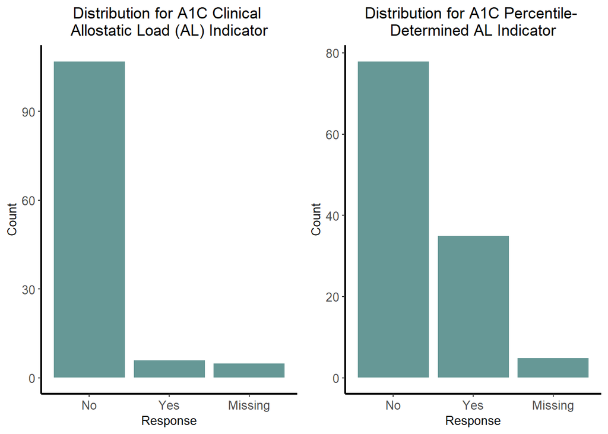

#### Clinical Categories

The distribution for hemoglobin A1C values (`a1c_hb`) alongside the clinical and percentile-determined allostatic load cutoffs are presented below.

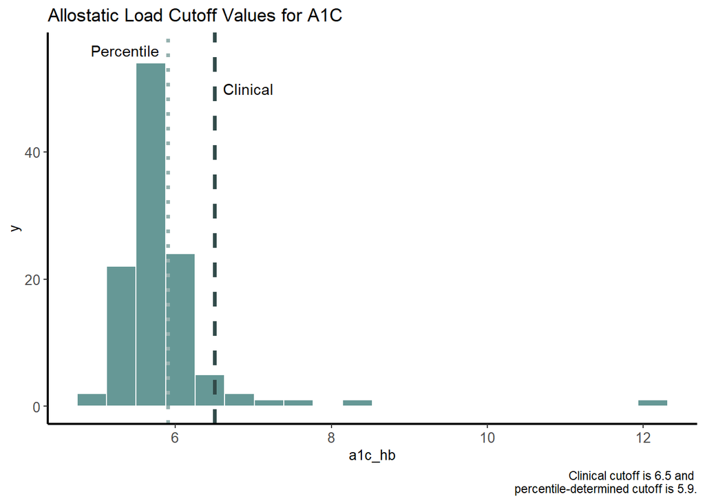

### Interleukin-6 (IL6) Description

These data include variables related to the Interleukin-6 assessment, including direct and plasma equivalent (PE) Interleukin-6 values for participants. Higher values indicate higher Interleukin-6. The PE value was used to calculate allostatic load indicators.

The missing data rule was not applied since composite variables were based on a single item. Missing data for each variable is presented in the descriptive statistics table below.

#### Value Labels

The value labels for all `_note` variables (`il6_punch_note`, `il6_assay_note`, and `il6_result_note`) are below:

| 1 |
| --- |
| Blank punch |

Allostatic load indicators, `il6_cal` and `il6_pal` are dichotomous:

| 0 | 1 |
| --- | --- |
| No | Yes |

#### Variables

All IL6 variables are presented in the following table.

| Variable | Description | Notes |
| --- | --- | --- |
| dbs_id | Unique ID for each assay |  |
| family | Participant ID |  |
| il6_direct | Direct Interleukin-6 analyte concentrate obtained from dried blood spot |  |
| il6_pe | Plasma-equivalent Interleukin-6 analyte concentration |  |
| il6_punch_note | Note made by technician during sample preparation (punching) | When multiple notes were provided, they are separated by a semi-colon |
| il6_assay_note | Note made by technician during assay | When multiple notes were provided, they are separated by a semi-colon |
| il6_result_note | Note indicating reportability of values | When multiple notes were provided, they are separated by a semi-colon |
| il6_plate | ID for the plate used during assay |  |
| il6_date | Date of assay |  |
| il6_cal | Clinical allostatic load indicator for out-of-range Interleukin-6 |  |
| il6_pal | Percentile-based allostatic load indicator for out-of-range Interleukin-6 |  |

#### Composite Variables

Using the plasma-equivalent Interleukin-6 value, two allostatic load indicators were calculated. One based on the clinical cut-off for high Interleukin-6 (`il6_cal`) and the other is a percentile-based cut-off for high Interleukin-6 (`il6_pal`) defined as the top 25% of Interleukin-6 values.

| Variable Name | Description (# of items) | Composite Construction | Range* |
| --- | --- | --- | --- |
| il6_cal | Allostatic load indicator based on clinical cut-off for high Interleukin-6 (1) | `il6_pe` > 6 | 0-1 |
| il6_pal | Allostatic load indicator based on top 25% of Interleukin-6 values (1) | Top 25% of observed `il6_pe` values | 0-1 |

*Range of possible values

#### Descriptive Statistics

Descriptive statistics are presented below for key IL6 variables.

Raw Interleukin-6 values:

| Variable | Mean | SD | Range* | % Missing |
| --- | --- | --- | --- | --- |
| il6_direct | 0.53 | 0.77 | 0.2-5.62 | 58.47% |
| il6_pe | 3.71 | 12.18 | 0.62-86.54 | 58.47% |

*Range of data values

**Allostatic load indicators:**

| Variable | No N | No % | Yes N | Yes % | % Missing |  |
| --- | --- | --- | --- | --- | --- | --- |
| il6_cal | 47 | 39.8% | 2 | 1.7% |  | 58.47% |
| il6_pal | 36 | 30.5% | 13 | 11% | 58.47% |  |

**Data collection notes:**

| Variable | Blank punch N | Blank punch % | % NA* |  |
| --- | --- | --- | --- | --- |
| il6_punch_note | 69 | 58.5% |  | 41.5% |
| il6_assay_note | 69 | 58.5% | 41.5% |  |
| il6_result_note | 69 | 58.5% | 41.5% |  |

*NA = Not Applicable

#### Distributions

Distributions are presented below for the allostatic load indicators.

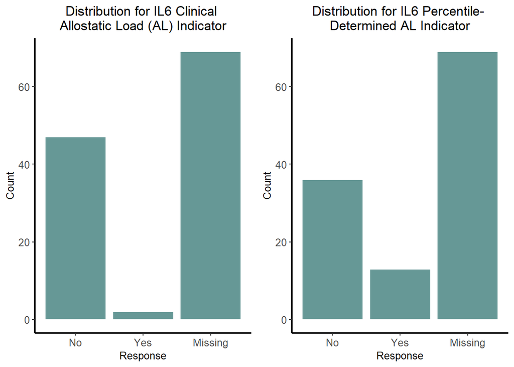

#### Clinical Categories

The distribution for plasma-equivalent Interleukin-6 values (`il6_pe`) alongside the clinical and percentile-determined allostatic load cutoffs are presented below.

[figure not shown]

## Other Health Measures

These data are in the `bio_archive.xlsx` file. Participant ID corresponds to the `family` variable, which can be used to merge additional data files from this study.

The original survey included exact dates/times and confidential health information. To protect participant confidentiality, exact dates/times were transformed into approximate time elapsed since date/time. Confidential health information was removed from this data file.

### Blood Pressure (BP) Description

These data include variables on systolic and diastolic blood pressure collected from participants. Higher scores indicate higher blood pressure.

### BP Variables

#### Value Labels

Allostatic load indicators, variables ending in `cal` or `pal`, are dichotomous:

| 0 | 1 |
| --- | --- |
| No | Yes |

#### Variables

All BP variables are presented in the following table:

| Variable | Description |
| --- | --- |
| bp1 | Systolic blood pressure measurement 1 |
| bp2 | Diastolic blood pressure measurement 1 |
| bp3 | Systolic blood pressure measurement 2 |
| bp4 | Diastolic blood pressure measurement 2 |
| bp_sys_avg | Average systolic blood pressure |
| bp_dia_avg | Average diastolic blood pressure |
| bp_sys_cal | Clinical allostatic load indicator of elevated systolic BP |
| bp_dia_cal | Clinical allostatic load indicator of elevated diastolic BP |
| bp_sys_pal | Percentile-based allostatic load indicator of elevated systolic BP |
| bp_dia_pal | Percentile-based allostatic load indicator of elevated diastolic BP |

#### Composite Variables

For both systolic and diastolic blood pressure, an average value and two allostatic load indicators were calculated. One based on the clinical cut off for high blood pressure (ending in `_cal`) and the other is a percentile-based cut-off for high blood pressure (ending in `pal`) defined as the top 25% of values.

| Variable Name | Description (# of items) | Composite Construction | Range* |
| --- | --- | --- | --- |
| bp_sys_avg | Average systolic blood pressure (2) | mean(`bp1`, `bp3`) |  |
| bp_dia_avg | Average diastolic blood pressure (2) | mean(`bp2`, `bp4`) |  |
| bp_sys_cal | Allostatic load indicator based on clinical cut-off for high systolic BP (1) | `bp_sys_avg` > 139 | 0-1 |
| bp_dia_cal | Allostatic load indicator based on clinical cut-off for high diastolic BP (1) | `bp_dia_avg` > 89 | 0-1 |
| bp_sys_pal | Allostatic load indicator based on top 25% of systolic BP values (1) | Top 25% of observed `bp_sys_avg` values | 0-1 |
| bp_dia_pal | Allostatic load indicator based on top 25% of diastolic BP values (1) | Top 25% of observed `bp_dia_avg` values | 0-1 |

*Range of possible values

#### Descriptive Statistics

Descriptive statistics are presented below for BP variables.

**Continuous values:**

| Variable | Mean | SD | Range* | % Missing |
| --- | --- | --- | --- | --- |
| bp1 | 120.28 | 15.36 | 87-168 | 1.6% |
| bp2 | 80.30 | 12.42 | 51-118 | 1.6% |
| bp3 | 118.90 | 15.97 | 79-184 | 2.4% |
| bp4 | 79.60 | 12.17 | 48-110 | 2.4% |
| bp_sys_avg | 119.51 | 14.01 | 87.5-155.5 | 1.6% |
| bp_dia_avg | 79.93 | 11.51 | 53.5-112 | 1.6% |

*Range of data values

**Allostatic load indicators:**

| Variable | No N | No % | Yes N | Yes % | % Missing |  |
| --- | --- | --- | --- | --- | --- | --- |
| bp_sys_cal | 111 | 88.8% | 12 | 9.6% |  | 1.6% |
| bp_dia_cal | 99 | 79.2% | 24 | 19.2% | 1.6% |  |
| bp_sys_pal | 92 | 73.6% | 31 | 24.8% | 1.6% |  |
| bp_dia_pal | 92 | 73.6% | 31 | 24.8% | 1.6% |  |

#### Distributions

Distributions are presented below for the average scores and allostatic load indicators.

**Average blood pressure:**

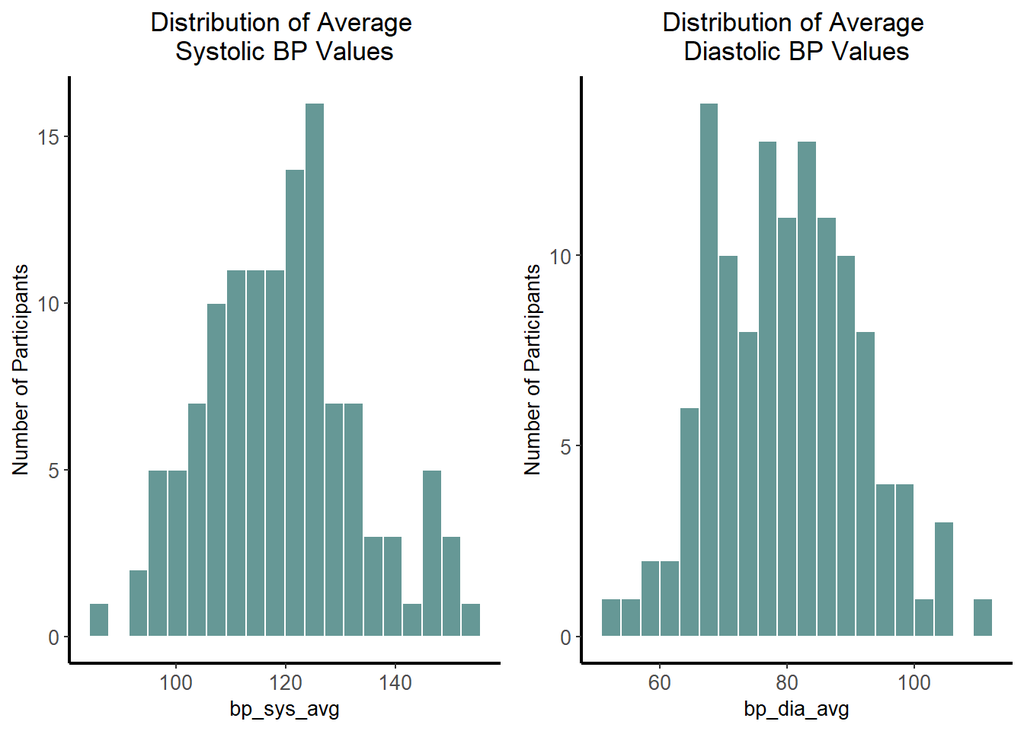

**Allostatic load indicators:**

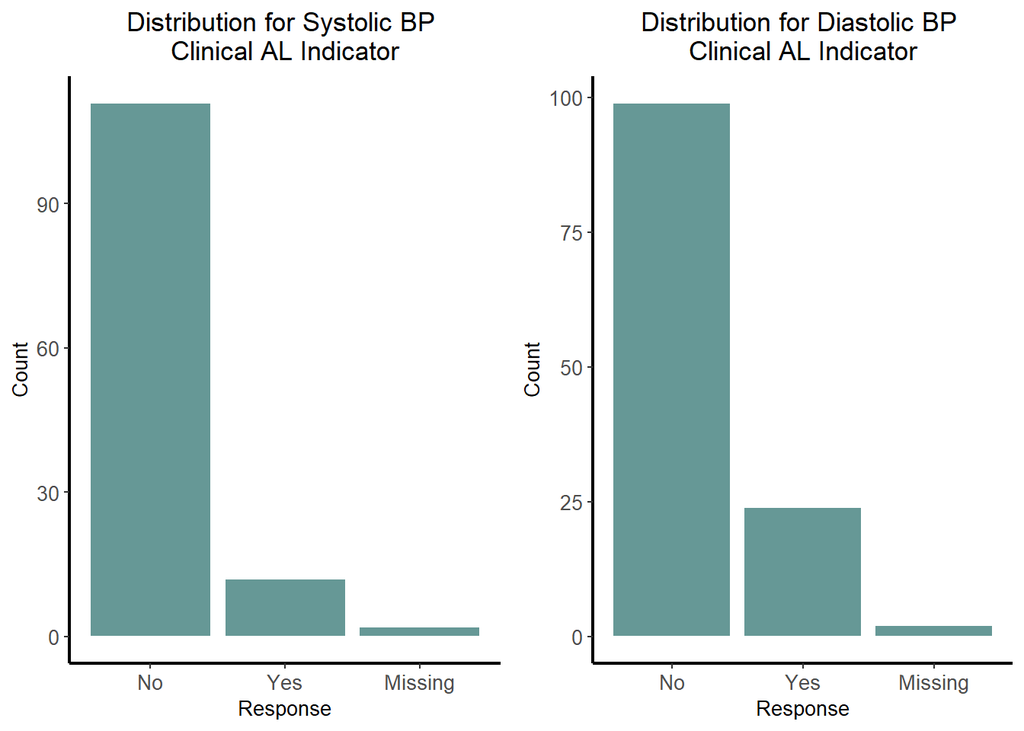

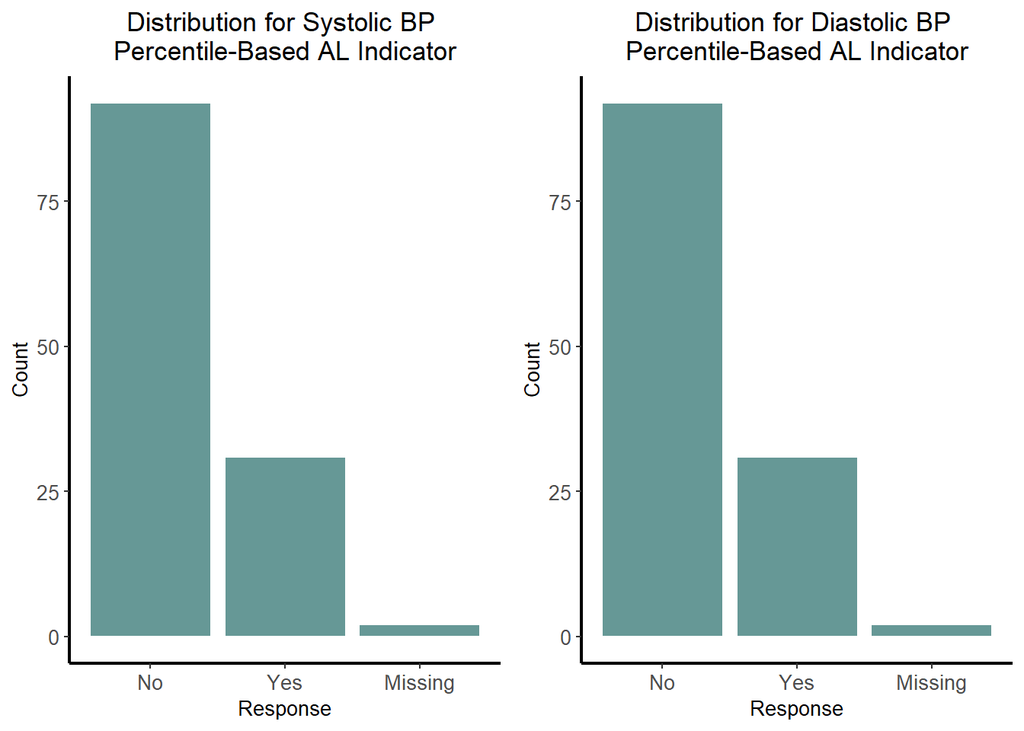

#### Clinical Categories

The distribution for average systolic and diastolic blood pressure (`bp_sys_avg` and `bp_dia_avg`) alongside the clinical and percentile-determined allostatic load cutoffs are presented below:

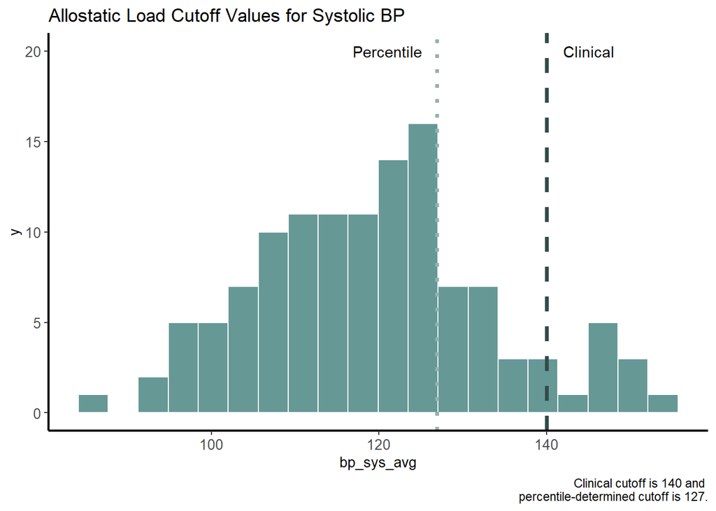

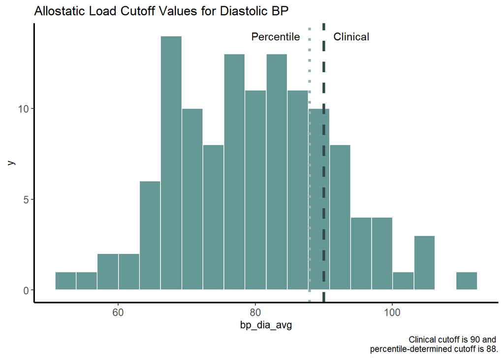

### Body Mass Index (BMI) Description

These data include variables on body mass index (BMI), including weight and height collected from participants. Higher scores indicate higher BMI.

Using BMI values, allostatic load indicators for high BMI were computed. The missing data rule was not applied since all participants who were asked BMI questions had valid data. Missing data for each variable presented in the descriptive statistics table below corresponds to “Not Applicable” values (`-55`).

### BMI Variables

#### Value Labels

Allostatic load indicators, `bmi_cal`, `bmi_pal`, are dichotomous:

| 0 | 1 |
| --- | --- |
| No | Yes |

#### Variables

All BMI variables are presented in the following table:

| Variable | Description |
| --- | --- |
| bmi1 | Height (cm) |
| bmi2 | Weight (kg) |
| bmi_score | Body mass index |
| bmi_cal | Clinical allostatic load indicator of out of range BMI |
| bmi_pal | Percentile-based allostatic load indicator of out of range BMI |

#### Composite Variables

Using height and weight, BMI was calculated. Two allostatic load indicators were calculated based on BMI. One based on the clinical cut off for high BMI (`bmi_cal`) and the other is a percentile-based cut-off for BMI (`bmi_pal`) defined as the top 25% of values.

| Variable Name | Description (# of items) | Composite Construction | Range* |
| --- | --- | --- | --- |
| bmi_score | Body mass index (2) | `bmi2` / ((`bmi1` / 100)^2) |  |
| bmi_cal | Allostatic load indicator based on clinical cut-off for high BMI (1) | `bmi_score` > 29 | 0-1 |
| bmi_pal | Allostatic load indicator based on top 25% of BMI values (1) | Top 25% of observed `bmi_score` values | 0-1 |

*Range of possible values

#### Descriptive Statistics

Descriptive statistics are presented below for BMI variables.

**Continuous values:**

| Variable | Mean | SD | Range* | % Missing |
| --- | --- | --- | --- | --- |
| bmi1 | 165.26 | 7.13 | 151.1-198.1 | 1.6% |
| bmi2 | 85.06 | 22.45 | 43.8-163.9 | 1.6% |
| bmi_score | 31.12 | 8.00 | 17.43-56.78 | 1.6% |

*Range of data values

**Allostatic load indicators:**

| Variable | No N | No % | Yes N | Yes % | % Missing |  |
| --- | --- | --- | --- | --- | --- | --- |
| bmi_cal | 64 | 51.2% | 59 | 47.2% |  | 1.6% |
| bmi_pal | 92 | 73.6% | 31 | 24.8% | 1.6% |  |

#### Distributions

Distributions are presented below for BMI scores and allostatic load indicators.

**BMI scores:**

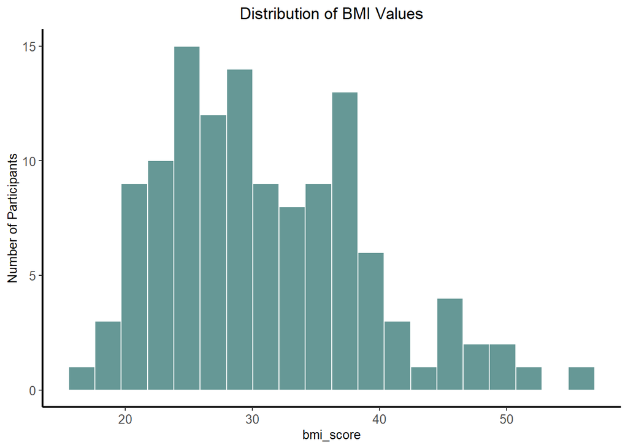

**Allostatic load indicators:**

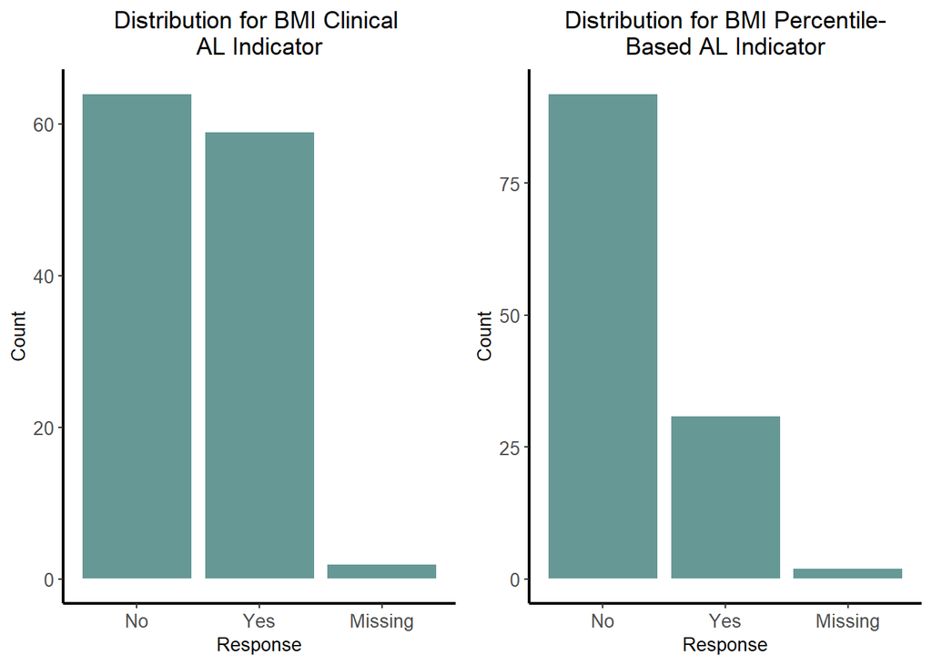

#### Clinical Categories

The distribution for BMI alongside the clinical and percentile-determined allostatic load cutoffs are presented below:

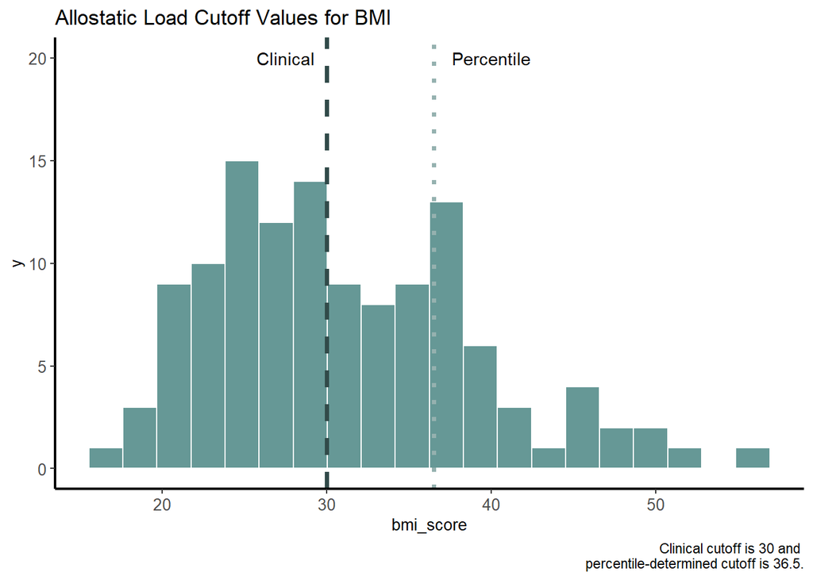

### Waist-to-Hip Ratio (WTH) Description

These data include variables on waist-to-hip ratio collected from participants. Higher scores indicate higher measurements.

Using waist and hip measurements, waist-to-hip ratio was calculated. Allostatic load indicators for high waist-to-hip ratio were computed. The missing data rule was not applied since all participants who were asked WTH questions had valid data. Missing data for each variable presented in the descriptive statistics table below corresponds to “Not Applicable” values (`-55`).

### WTH Variables

#### Value Labels

Allostatic load indicators, `wth_cal`, `wth_pal`, are dichotomous:

| 0 | 1 |
| --- | --- |
| No | Yes |

#### Variables

All WTH variables are presented in the following table:

| Variable | Description |
| --- | --- |
| wth1 | Waist circumference (cm) |
| wth2 | Hip Measurement (cm) |
| wth_ratio | Waist-to-hip ratio |
| wth_cal | Clinical allostatic load indicator of out of range waist-to-hip ratio |
| wth_pal | Percentile-based allostatic load indicator of out of range waist-to-hip ratio |

#### Composite Variables

Using waist circumference and hip measurement collected from participants, waist-to-hip ratio was calculated. Two allostatic load indicators were calculated based on waist-to-hip ratio. One based on the clinical cut off for high waist-to-hip ratio (`wth_cal`) and the other is a percentile-based cut-off for waist-to-hip ratio (`wth_pal`) defined as the top 25% of values.

| Variable Name | Description (# of items) | Composite Construction | Range* |
| --- | --- | --- | --- |
| wth_ratio | Waist-to-hip ratio (2) | `wth1`/`wth2` |  |
| wth_cal | Allostatic load indicator based on clinical cut-off for high waist-to-hip ratio (1) | `wth_ratio` > 0.84 | 0-1 |
| wth_pal | Allostatic load indicator based on top 25% of waist-to-hip ratio values (1) | Top 25% of observed `wth_ratio` values | 0-1 |

*Range of possible values

#### Descriptive Statistics

Descriptive statistics are presented below for WTH variables.

**Continuous values:**

| Variable | Mean | SD | Range* | % Missing |
| --- | --- | --- | --- | --- |
| wth1 | 101.79 | 19.65 | 56-161.9 | 1.6% |
| wth2 | 110.76 | 15.92 | 57-153.8 | 1.6% |
| wth_ratio | 0.92 | 0.09 | 0.56-1.15 | 1.6% |

*Range of data values

**Allostatic load indicators:**

| Variable | No N | No % | Yes N | Yes % | % Missing |  |
| --- | --- | --- | --- | --- | --- | --- |
| wth_cal | 28 | 22.4% | 95 | 76% |  | 1.6% |
| wth_pal | 92 | 73.6% | 31 | 24.8% | 1.6% |  |

#### Distributions

Distributions are presented below for WTH ratio and allostatic load indicators.

**WTH ratio values:**

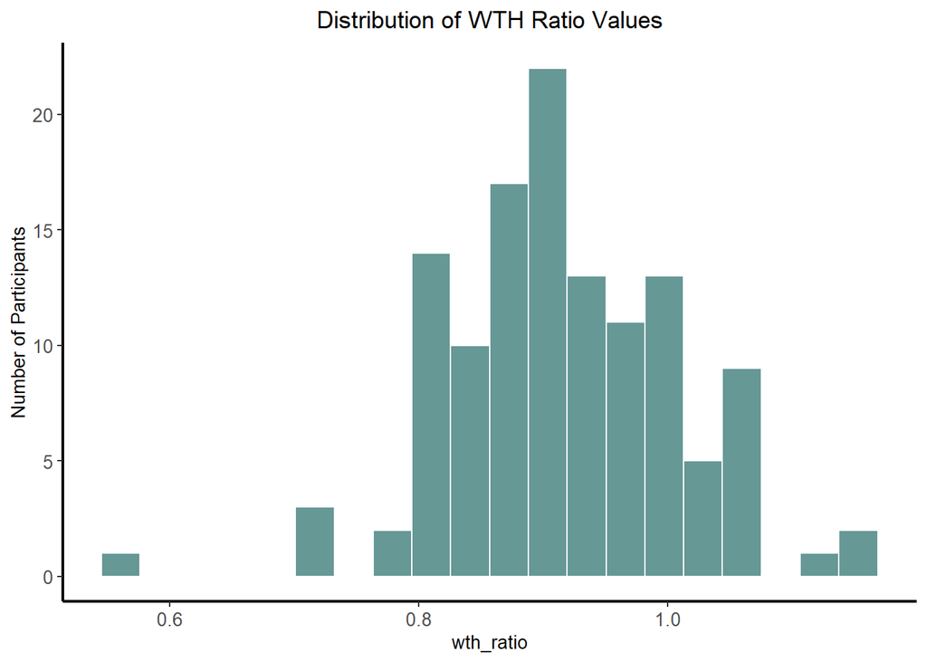

**Allostatic load indicators:**

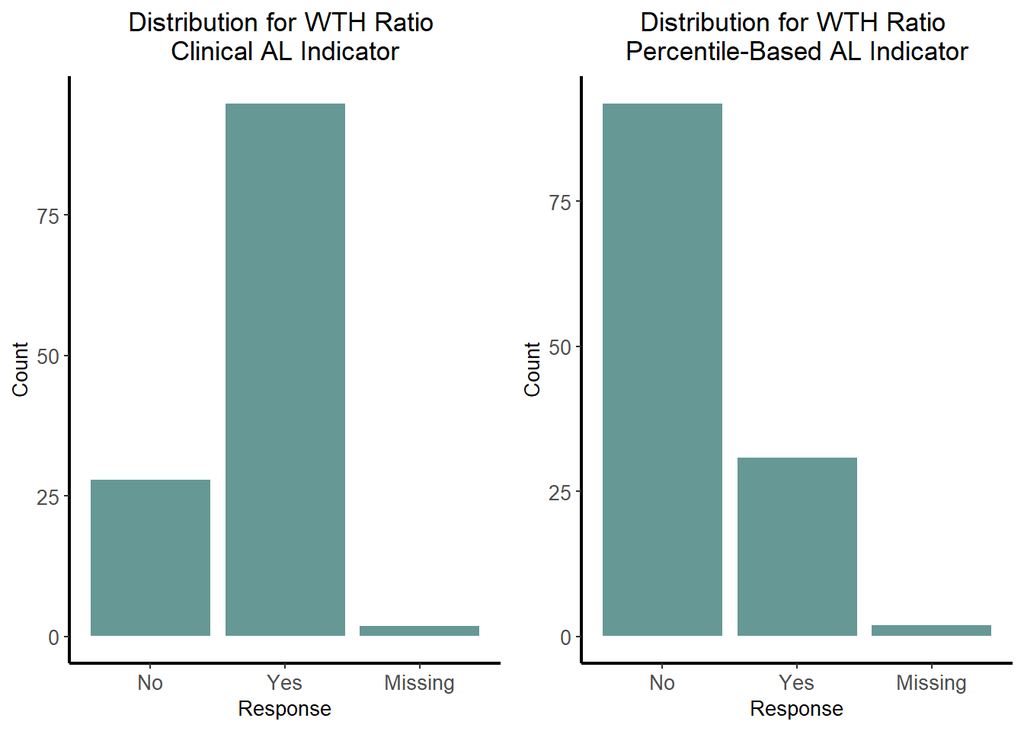

#### Clinical Categories

The distribution for waist-to-hip ratio alongside the clinical and percentile-determined allostatic load cutoffs are presented below:

[figure not shown]

### Peak Expiratory Flow (PEF) Description

These data include variables on peak expiratory flow collected from participants, including direct peak expiratory flow and forced expiratory volume measurements. Lower scores indicate worse performance.

### PEF Variables

#### Value Labels

Allostatic load indicators, `pef_cal`, `pef_pal`, are dichotomous:

| 0 | 1 |
| --- | --- |
| No | Yes |

#### Variables

All PEF variables are presented in the following table:

| Variable | Description |
| --- | --- |
| pef1 | Peak expiratory flow measurement 1 |
| pef2 | Peak expiratory flow measurement 2 |
| pef3 | Peak expiratory flow measurement 3 |
| pef4 | Forced expiratory volume measurement 1 |
| pef5 | Forced expiratory volume measurement 2 |
| pef6 | Forced expiratory volume measurement 3 |
| pef_avg | Average peak expiratory flow |
| pef_cal | Clinical allostatic load indictor of out of range peak expiratory flow |
| pef_pal | Percentile-based allostatic load indictor of out of range peak expiratory flow |

#### Composite Variables

| Variable Name | Description (# of items) | Composite Construction | Range* |
| --- | --- | --- | --- |
| pef_avg | Average peak expiratory flow (3) | (`pef1`+`pef2`+`pef3`) / 3 |  |
| pef_cal | Allostatic load indicator based on clinical cut-off for low peak expiratory flow (1) | `pef_avg` < 320 | 0-1 |
| pef_pal | Allostatic load indicator based on bottom 25% of peak expiratory flow values (1) | Bottom 25% of observed `pef_avg` values | 0-1 |

*Range of possible values

#### Descriptive Statistics

Descriptive statistics are presented below for PEF variables.

**Continuous values:**

| Variable | Mean | SD | Range* | % Missing |
| --- | --- | --- | --- | --- |
| pef1 | 264.36 | 110.73 | 57-540 | 2.4% |
| pef2 | 286.87 | 117.19 | 57-570 | 2.4% |
| pef3 | 292.30 | 118.32 | 53-591 | 2.4% |
| pef4 | 2.65 | 0.74 | 0.87-4.14 | 2.4% |
| pef5 | 2.77 | 0.76 | 0.33-4.25 | 2.4% |
| pef6 | 2.82 | 0.78 | 0.9-4.45 | 2.4% |
| pef_avg | 281.17 | 109.01 | 60.33-566.33 | 2.4% |

*Range of data values

**Allostatic load indicators:**

| Variable | No N | No % | Yes N | Yes % | % Missing |  |
| --- | --- | --- | --- | --- | --- | --- |
| pef_cal | 48 | 38.4% | 74 | 59.2% |  | 2.4% |
| pef_pal | 91 | 72.8% | 31 | 24.8% | 2.4% |  |

#### Distributions

Distributions are presented below for the average score and allostatic load indicators.

**PEF average:**

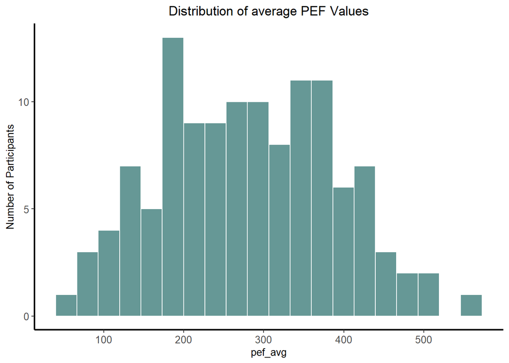

**Allostatic load indicators:**

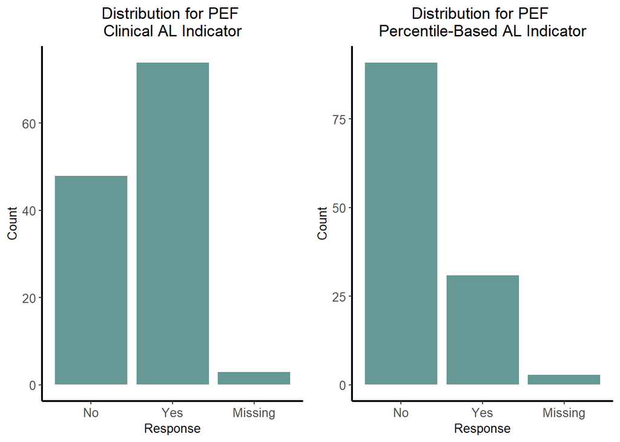

#### Clinical Categories

The distribution for average peak expiratory flow alongside the clinical and percentile-determined allostatic load cutoffs are presented below:

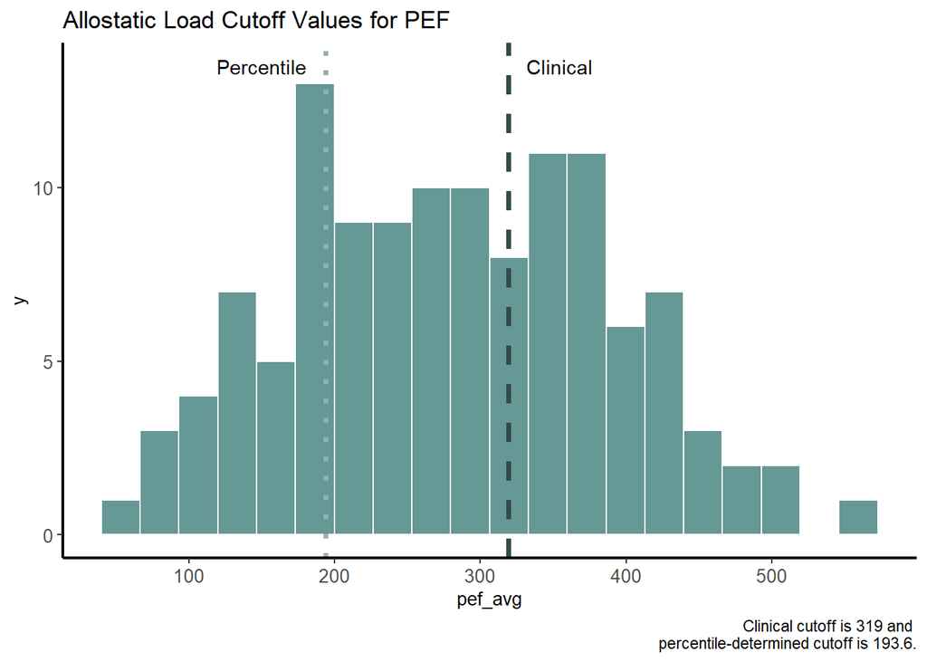

### Pulse Reading (PULSE) Description

These data include variables on pulse readings collected from participants. Higher scores indicate increased resting pulse rate.

### PULSE Variables

#### Value Labels

Allostatic load indicators, `pulse_cal`, `pulse_pal`, are dichotomous:

| 0 | 1 |
| --- | --- |
| No | Yes |

#### Variables

All PULSE variables are presented in the following table:

| Variable | Description |
| --- | --- |
| pulse1 | Pulse reading 1 |
| pulse2 | Pulse reading 2 |
| pulse_avg | Average resting pulse |
| pulse_cal | Clinical allostatic load indicator of out of range resting pulse |
| pulse_pal | Percentile-based allostatic load indicator of out of range pulse |

#### Composite Variables

Using both resting pulse readings, average pulse rate was calculated. Two allostatic load indicators were calculated based on average pulse rate. One based on the clinical cut off for high resting pulse (`pulse_cal`) and the other is a percentile-based cut-off for resting pulse (`pulse_pal`) defined as the top 25% of values.

| Variable Name | Description (# of items) | Composite Construction | Range* |
| --- | --- | --- | --- |
| pulse_avg | Average resting pulse (2) | (`pulse1`+`pulse2`) / 2 |  |
| pulse_cal | Allostatic load indicator based on clinical cut-off for high resting pulse (1) | `pulse_avg` > 89 | 0-1 |
| pulse_pal | Allostatic load indicator based on top 25% of average resting pulse values (1) | Top 25% of observed `pulse_avg` values | 0-1 |

*Range of possible values

#### Descriptive Statistics

Descriptive statistics are presented below for PULSE variables.

**Continuous values:**

| Variable | Mean | SD | Range* | % Missing |
| --- | --- | --- | --- | --- |
| pulse1 | 81.34 | 12.65 | 47-114 | 5.6% |
| pulse2 | 79.16 | 12.96 | 49-120 | 11.2% |
| pulse_avg | 80.33 | 12.29 | 48-116 | 4% |

*Range of data values

**Allostatic load indicators:**

| Variable | No N | No % | Yes N | Yes % | % Missing |  |
| --- | --- | --- | --- | --- | --- | --- |
| pulse_cal | 98 | 78.4% | 22 | 17.6% |  | 4% |
| pulse_pal | 89 | 71.2% | 31 | 24.8% | 4% |  |

#### Distributions

Distributions are presented below for average resting pulse and allostatic load indicators.

**Average PULSE value:**

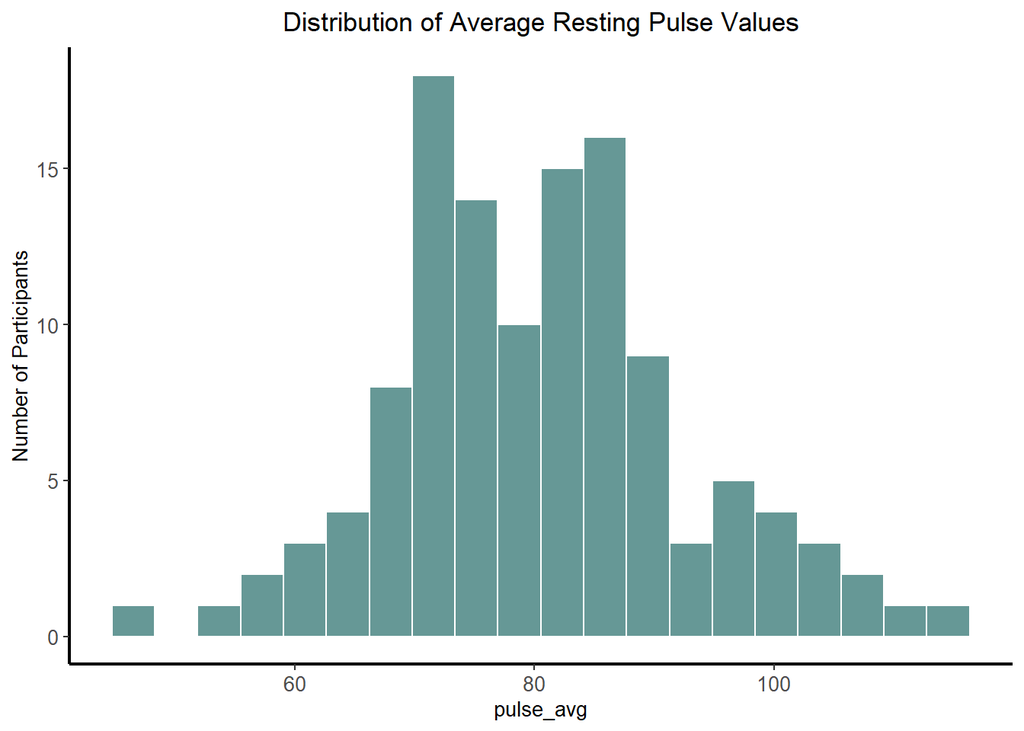

**Allostatic load indicators:**

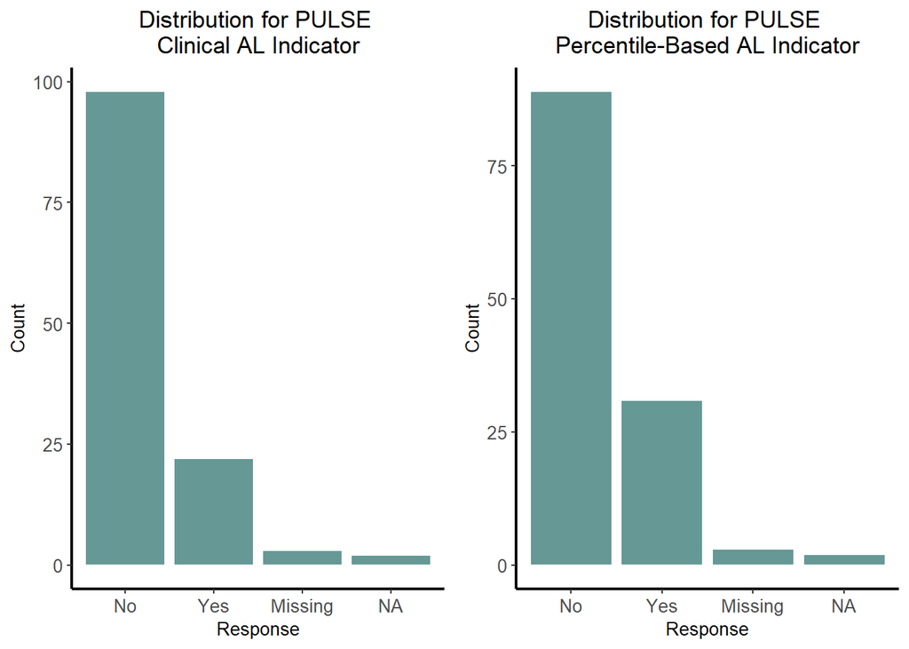

#### Clinical Categories

The distribution for average resting pulse rate alongside the clinical and percentile-determined allostatic load cutoffs are presented below:

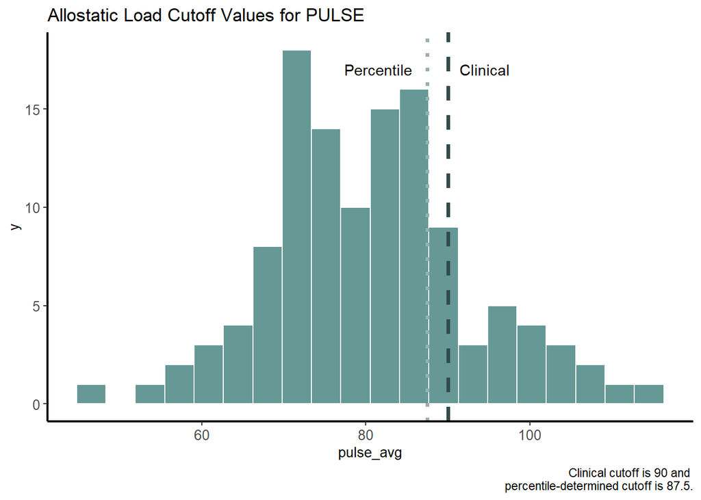

### Total Allostatic Load (TOTAL) Description

These data include one variable representing total allostatic load. It is a count of all allostatic load indicators in the full data set, including allostatic load indicators from the Dried Blood Spot assessment (DBS). Higher scores indicate increased allostatic load.

The missing data rule was applied. Calculations were completed for participants that has less than 20% missing data on allostatic load indicators. Missing data for total allostatic load is presented in the descriptive statistics table below.

### TOTAL Variables

#### Value Labels

There are no value labels, this variable is a count.

#### Variables

Information for the `total_al` variable is presented in the following table:

| Variable | Description |
| --- | --- |
| total_al | Total allostatic load score (sum of all clinical AL indicators) |

#### Composite Variables

The total allostatic load score was calculated by creating a sum of all clinical allostatic load indicator variables (ending in `_cal`), including those in the DBS data collection. The percentile-based allostatic load indicator was used for Epstein-Barr virus (`ebv_pal`) since a clinical indicator was not calculated.

| Variable Name | Description (# of items) | Composite Construction | Range* |
| --- | --- | --- | --- |
| total_al | Total allostatic load score (13 | `bp_sys_cal` + `bp_dia_cal` + `bmi_cal` + `wth_cal` + `pef_cal` + `pulse_cal`+ `a1c_cal` + `cho_cal` + `crp_cal` + `ebv_pal` + `hdl_cal` + `il6_cal` + `trp_cal` | 0-13 |

*Range of possible values

#### Descriptive Statistics

Descriptive statistics are presented below for the total allostatic load score:

| Variable | Mean | SD | Range* | % Missing |
| --- | --- | --- | --- | --- |
| total_al | 3.97 | 1.54 | 1-7 | 18.4% |

*Range of data values

#### Distributions

Distributions are presented below for the total allostatic load score:

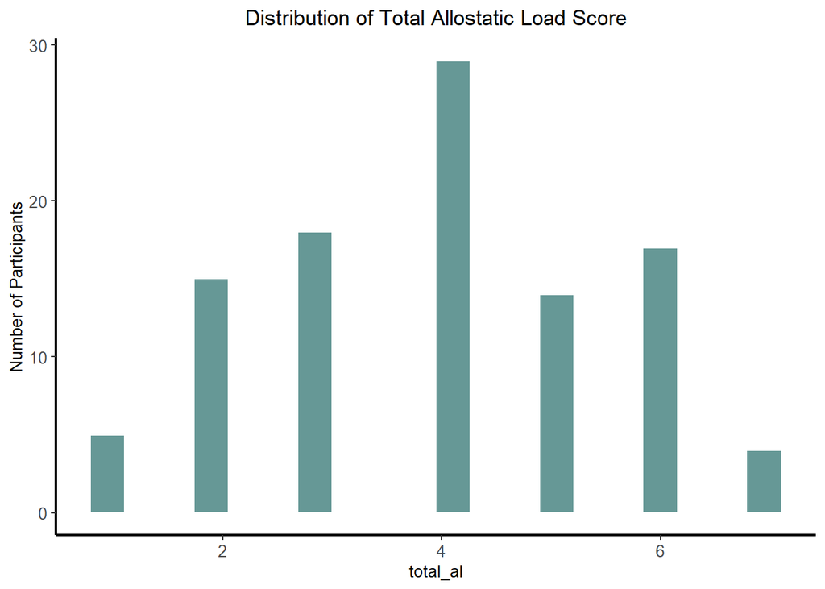

### RAND Health Survey, SF-36 (RHS) Description

The RAND Health Survey SF-36 (RHS) is designed to measure health concepts, such as limitations, well-being, and general health.

Item numbers in this data set may not match original item numbers from the RHS-SF36. See the following table for corresponding item numbers from the original RHS-SF36:

| Variable | Original Item |
| --- | --- |
| rhs1 | Item 1 |
| rhs2 | Item 13 |
| rhs3 | Item 14 |
| rhs4 | Item 15 |
| rhs5 | Item 16 |
| rhs6 | Item 17 |
| rhs7 | Item 18 |
| rhs8 | Item 19 |
| rhs9 | Item 33 |
| rhs10 | Item 34 |
| rhs11 | Item 35 |
| rhs12 | Item 36 |

Raw RHS variables were recoded per the [RHS-SF36 scoring guide](https://www.rand.org/health-care/surveys_tools/mos/36-item-short-form/scoring.html). All recoded variables end with `_p` and range from 0 to 100. Higher scores indicate a more favorable health state. Recoded variables were used to calculate the subscales.

The missing data rule was not applied since all participants had less than 20% missing data.

### RHS Variables

#### Value labels

The value labels for `rhs1` are below:

| 1 | 2 | 3 | 4 | 5 |
| --- | --- | --- | --- | --- |
| Excellent | Very good | Good | Fair | Poor |

Variables `rhs2`, `rhs3`, `rhs4`, `rhs5`, `rhs6`, `rhs7`, and `rhs8` are dichotomous:

| 0 | 1 |
| --- | --- |
| No | Yes |

The value labels for `rhs9`, `rhs10`, `rhs11`, and `rhs12` are as follows:

| 1 | 2 | 3 | 4 | 5 |
| --- | --- | --- | --- | --- |
| Definitely true | Mostly true | Don’t know | Mostly false | Definitely false |

#### Survey Items

All RHS survey items and recoded variables are presented in the following table:

| Variable | Description |
| --- | --- |
| rhs1 | In general, would you say your health is: |
| During the past 4 weeks, have you had any of the following problems with your work or other regular activities as a result of your physical health? |  |
| rhs2 | Cut down the amount of time you spent on work or other activities |
| rhs3 | Accomplished less than you would like |
| rhs4 | Were limited in the kind of work or other activities |
| rhs5 | Had difficulty performing the work or other activities (for example, it took extra effort) |
| During the past 4 weeks, have you had any of the following problems with your work or other regular daily activities as a result of any emotional problems (such as feeling depressed or anxious)? |  |
| rhs6 | Cut down the amount of time you spent on work or other activities |
| rhs7 | Accomplished less than you would like |
| rhs8 | Didn't do work or other activities as carefully as usual |
| How true or false is each of the following statements for you. |  |
| rhs9 | I seem to get sick a little easier than other people |
| rhs10 | I am as healthy as anybody I know |
| rhs11 | I expect my health to get worse |
| rhs12 | My health is excellent |
| Recoded variables for computing subscales: |  |
| rhs1_p | Recoded `rhs1` variable for calculating subscales |
| rhs2_p | Recoded `rhs2` variable for calculating subscales |
| rhs3_p | Recoded `rhs3` variable for calculating subscales |
| rhs4_p | Recoded `rhs4` variable for calculating subscales |
| rhs5_p | Recoded `rhs5` variable for calculating subscales |
| rhs6_p | Recoded `rhs6` variable for calculating subscales |
| rhs7_p | Recoded `rhs7` variable for calculating subscales |
| rhs8_p | Recoded `rhs8` variable for calculating subscales |
| rhs9_p | Recoded `rhs9` variable for calculating subscales |
| rhs10_p | Recoded `rhs10` variable for calculating subscales |
| rhs11_p | Recoded `rhs11` variable for calculating subscales |
| rhs12_p | Recoded `rhs12` variable for calculating subscales |

#### Subscales

Using the recoded RHS variables (`_p`), subscales were computed by averaging individual items per the [RHS-SF36 scoring guide](https://www.rand.org/health-care/surveys_tools/mos/36-item-short-form/scoring.html).

| Variable Name | Scale (# of items) | Scale Construction | Range* |
| --- | --- | --- | --- |
| rhs_health | General health (4) | mean(`rhs9_p`, `rhs10_p`, `rhs11_p`, `rhs12_p`) | 0-100 |
| rhs_phys_limit | Role limitations due to physical health (4) | mean(`rhs2_p`, `rhs3_p`, `rhs4_p`, `rhs5_p`) | 0-100 |
| rhs_emo_limit | Role limitations due to emotional problems (3) | mean(`rhs6_p`, `rhs7_p`, `rhs8_p`) | 0-100 |

*Range of possible values

#### Descriptive Statistics

Descriptive statistics are presented below for all RHS variables.

**Non-binary variables:**

[output not shown]

*Range of data values

**Binary variables:**

| Variable | No N | No % | Yes N | Yes % | % Missing |  |
| --- | --- | --- | --- | --- | --- | --- |
| rhs2 | 99 | 79.2% | 26 | 20.8% |  | 0% |
| rhs3 | 82 | 65.6% | 43 | 34.4% | 0% |  |
| rhs4 | 95 | 76% | 30 | 24% | 0% |  |
| rhs5 | 85 | 68% | 40 | 32% | 0% |  |
| rhs6 | 81 | 64.8% | 44 | 35.2% | 0% |  |
| rhs7 | 70 | 56% | 55 | 44% | 0% |  |
| rhs8 | 88 | 70.4% | 37 | 29.6% | 0% |  |